# Starbucks Capstone Challenge

[figure not shown]

### Introduction

This data set contains simulated data that mimics customer behavior on the Starbucks rewards mobile app. Once every few days, Starbucks sends out an offer to users of the mobile app. An offer can be merely an advertisement for a drink or an actual offer such as a discount or BOGO (buy one get one free). Some users might not receive any offer during certain weeks.

Not all users receive the same offer, and that is the challenge to solve with this data set.

Your task is to combine transaction, demographic and offer data to determine which demographic groups respond best to which offer type. This data set is a simplified version of the real Starbucks app because the underlying simulator only has one product whereas Starbucks actually sells dozens of products.

Every offer has a validity period before the offer expires. As an example, a BOGO offer might be valid for only 5 days. You'll see in the data set that informational offers have a validity period even though these ads are merely providing information about a product; for example, if an informational offer has 7 days of validity, you can assume the customer is feeling the influence of the offer for 7 days after receiving the advertisement.

You'll be given transactional data showing user purchases made on the app including the timestamp of purchase and the amount of money spent on a purchase. This transactional data also has a record for each offer that a user receives as well as a record for when a user actually views the offer. There are also records for when a user completes an offer.

Keep in mind as well that someone using the app might make a purchase through the app without having received an offer or seen an offer.

# ستاربكس كابستون التحدي

### مقدمة

تحتوي مجموعة البيانات هذه على بيانات محاكاة تحاكي سلوك العميل على تطبيق ستاربكس لمكافآت الجوّال. مرة كل بضعة أيام، ترسل ستاربكس عرضًا لمستخدمي تطبيق الجوّال. يمكن أن يكون العرض مجرد إعلان عن مشروب أو عرض فعلي مثل الخصم أو BOGO (شراء واحد الحصول على واحد مجانا). قد لا يتلقى بعض المستخدمين أي عرض خلال أسابيع معينة.

لا يتلقى جميع المستخدمين نفس العرض ، وهذا هو التحدي الذي يجب حله مع مجموعة البيانات هذه.

مهمتك هي الجمع بين البيانات المعاملة والديموغرافية والعرض لتحديد المجموعات الديموغرافية التي تستجيب بشكل أفضل لنوع العرض. مجموعة البيانات هذه هي نسخة مبسطة من تطبيق ستاربكس الحقيقي لأن المحاكية الأساسية لديها منتج واحد فقط في حين تبيع ستاربكس بالفعل عشرات المنتجات.

كل عرض له فترة صلاحية قبل انتهاء العرض. على سبيل المثال، قد يكون عرض BOGO صالحًا لمدة 5 أيام فقط. سترى في مجموعة البيانات أن العروض المعلوماتية لها فترة صلاحية على الرغم من أن هذه الإعلانات تقدم فقط معلومات حول منتج ما؛ على سبيل المثال، إذا كان العرض الإعلامي له 7 أيام من الصلاحية، يمكنك أن تفترض أن العميل يشعر بتأثير العرض لمدة 7 أيام بعد تلقي الإعلان.

سيتم إعطائك بيانات معاملات توضح عمليات الشراء التي قام بها المستخدم على التطبيق بما في ذلك الطابع الزمني للشراء ومقدار المال الذي يتم إنفاقه على عملية الشراء. تحتوي بيانات المعاملات هذه أيضاً على سجل لكل عرض يتلقاه المستخدم بالإضافة إلى سجل عند عرض العرض بالفعل. هناك أيضا سجلات عندما يكمل المستخدم عرضا.

ضع في اعتبارك أيضًا أن شخصًا يستخدم التطبيق قد يقوم بإجراء عملية شراء من خلال التطبيق دون تلقي عرض أو رؤية عرض.

### Example

To give an example, a user could receive a discount offer buy 10 dollars get 2 off on Monday. The offer is valid for 10 days from receipt. If the customer accumulates at least 10 dollars in purchases during the validity period, the customer completes the offer.

However, there are a few things to watch out for in this data set. Customers do not opt into the offers that they receive; in other words, a user can receive an offer, never actually view the offer, and still complete the offer. For example, a user might receive the "buy 10 dollars get 2 dollars off offer", but the user never opens the offer during the 10 day validity period. The customer spends 15 dollars during those ten days. There will be an offer completion record in the data set; however, the customer was not influenced by the offer because the customer never viewed the offer.

### مثال

على سبيل المثال ، يمكن للمستخدم الحصول على عرض خصم شراء 10 دولار الحصول على 2 قبالة يوم الاثنين. يسري العرض لمدة 10 أيام من تاريخ استلامه. إذا كان العميل يجمع ما لا يقل عن 10 دولار في المشتريات خلال فترة الصلاحية، العميل يكمل العرض.

ومع ذلك ، هناك بعض الأشياء التي يجب مراقبتها في مجموعة البيانات هذه. الزبائن لا يختارون في العروض التي يتلقونها. وبعبارة أخرى، يمكن للمستخدم تلقي عرض، لا عرض العرض في الواقع، ولا يزال إكمال العرض. على سبيل المثال ، قد يحصل المستخدم على "شراء 10 دولار الحصول على 2 دولار من العرض" ، ولكن المستخدم لا يفتح العرض خلال فترة الصلاحية 10 أيام. ينفق العميل 15 دولار خلال تلك الأيام العشرة. وسيكون هناك سجل إنجاز العرض في مجموعة البيانات؛ ومع ذلك، لم يتأثر العميل بالعرض لأن العميل لم ينظر إلى العرض.

### Cleaning

This makes data cleaning especially important and tricky.

You'll also want to take into account that some demographic groups will make purchases even if they don't receive an offer. From a business perspective, if a customer is going to make a 10 dollar purchase without an offer anyway, you wouldn't want to send a buy 10 dollars get 2 dollars off offer. You'll want to try to assess what a certain demographic group will buy when not receiving any offers.

### تنظيف

وهذا يجعل تنظيف البيانات مهمًا وصعبًا بشكل خاص.

كما أنك تريد أن تأخذ في الاعتبار أن بعض المجموعات السكانية ستقوم بعمليات شراء حتى إذا لم تتلق عرضًا. من وجهة نظر تجارية ، إذا كان العميل هو الذهاب الى جعل شراء 10 دولار دون عرض على أي حال ، فإنك لا تريد أن ترسل شراء 10 دولار الحصول على 2 دولار قبالة العرض. ستحتاج إلى محاولة تقييم ما ستشتريه مجموعة سكانية معينة عند عدم تلقي أي عروض.

### Final Advice

Because this is a capstone project, you are free to analyze the data any way you see fit. For example, you could build a machine learning model that predicts how much someone will spend based on demographics and offer type. Or you could build a model that predicts whether or not someone will respond to an offer. Or, you don't need to build a machine learning model at all. You could develop a set of heuristics that determine what offer you should send to each customer (i.e., 75 percent of women customers who were 35 years old responded to offer A vs 40 percent from the same demographic to offer B, so send offer A).

### نصيحة نهائية

لأن هذا هو مشروع capstone ، أنت حر في تحليل البيانات بأي طريقة تراها مناسبة. على سبيل المثال، يمكنك إنشاء نموذج تعلم آلي يتنبأ بكمية إنفاق شخص ما استنادًا إلى التركيبة السكانية ونوع العرض. أو يمكنك بناء نموذج يتنبأ بما إذا كان شخص ما سيستجيب لعرض أم لا. أو، لا تحتاج إلى بناء نموذج التعلم الآلي على الإطلاق. يمكنك تطوير مجموعة من الاستدلالات التي تحدد العرض الذي يجب إرساله إلى كل عميل (أي أن 75 في المائة من العملاء من النساء اللواتي كن في الخامسة والثلاثين من العمر استجابن لتقديم A مقابل 40 في المائة من نفس العرض السكاني لتقديم B ، لذا أرسل العرض A).

# Data Sets

The data is contained in three files:

- portfolio.json - containing offer ids and meta data about each offer (duration, type, etc.)
- profile.json - demographic data for each customer
- transcript.json - records for transactions, offers received, offers viewed, and offers completed

Here is the schema and explanation of each variable in the files:

**portfolio.json**

- id (string) - offer id
- offer_type (string) - type of offer ie BOGO, discount, informational
- difficulty (int) - minimum required spend to complete an offer
- reward (int) - reward given for completing an offer
- duration (int) - time for offer to be open, in days
- channels (list of strings)

**profile.json**

- age (int) - age of the customer
- became_member_on (int) - date when customer created an app account
- gender (str) - gender of the customer (note some entries contain 'O' for other rather than M or F)
- id (str) - customer id
- income (float) - customer's income

**transcript.json**

- event (str) - record description (ie transaction, offer received, offer viewed, etc.)
- person (str) - customer id
- time (int) - time in hours since start of test. The data begins at time t=0
- value - (dict of strings) - either an offer id or transaction amount depending on the record

**Note:** If you are using the workspace, you will need to go to the terminal and run the command `conda update pandas` before reading in the files. This is because the version of pandas in the workspace cannot read in the transcript.json file correctly, but the newest version of pandas can. You can access the termnal from the orange icon in the top left of this notebook.

You can see how to access the terminal and how the install works using the two images below. First you need to access the terminal:

[figure not shown]

Then you will want to run the above command:

[figure not shown]

Finally, when you enter back into the notebook (use the jupyter icon again), you should be able to run the below cell without any errors.

```python
# Load Library
import pandas as pd
import numpy as np
import matplotlib.pyplot as plt
import math
import json
% matplotlib inline

import seaborn as sns

sns.set()
```

```python
# read in the json files
portfolio = pd.read_json('data/portfolio.json', orient='records', lines=True)
profile = pd.read_json('data/profile.json', orient='records', lines=True)
transcript = pd.read_json('data/transcript.json', orient='records', lines=True)
```

# Data Analysis

### Data Exploration and Visualization

### portfolio

```python
portfolio.head(10)
#   id         (string) - offer id
#   offer_type (string) - type of offer ie BOGO, discount, informational
#   difficulty (int)    - minimum required spend to complete an offer
#   reward     (int)    - reward given for completing an offer
#   duration   (int)    - time for offer to be open, in days
#   channels   (list of strings)
```

|  | channels | difficulty | duration | id | offer_type | reward |
| --- | --- | --- | --- | --- | --- | --- |
| 0 | [email, mobile, social] | 10 | 7 | ae264e3637204a6fb9bb56bc8210ddfd | bogo | 10 |
| 1 | [web, email, mobile, social] | 10 | 5 | 4d5c57ea9a6940dd891ad53e9dbe8da0 | bogo | 10 |
| 2 | [web, email, mobile] | 0 | 4 | 3f207df678b143eea3cee63160fa8bed | informational | 0 |
| 3 | [web, email, mobile] | 5 | 7 | 9b98b8c7a33c4b65b9aebfe6a799e6d9 | bogo | 5 |
| 4 | [web, email] | 20 | 10 | 0b1e1539f2cc45b7b9fa7c272da2e1d7 | discount | 5 |
| 5 | [web, email, mobile, social] | 7 | 7 | 2298d6c36e964ae4a3e7e9706d1fb8c2 | discount | 3 |
| 6 | [web, email, mobile, social] | 10 | 10 | fafdcd668e3743c1bb461111dcafc2a4 | discount | 2 |
| 7 | [email, mobile, social] | 0 | 3 | 5a8bc65990b245e5a138643cd4eb9837 | informational | 0 |
| 8 | [web, email, mobile, social] | 5 | 5 | f19421c1d4aa40978ebb69ca19b0e20d | bogo | 5 |
| 9 | [web, email, mobile] | 10 | 7 | 2906b810c7d4411798c6938adc9daaa5 | discount | 2 |

```python
portfolio.info()
```

```
<class 'pandas.core.frame.DataFrame'>
RangeIndex: 10 entries, 0 to 9
Data columns (total 6 columns):
channels      10 non-null object
difficulty    10 non-null int64
duration      10 non-null int64
id            10 non-null object
offer_type    10 non-null object
reward        10 non-null int64
dtypes: int64(3), object(3)
memory usage: 560.0+ bytes
```

```python
# checking the count of each offer type
portfolio.offer_type.value_counts()
```

```
bogo             4
discount         4
informational    2
Name: offer_type, dtype: int64
```

### profile

```python
profile.head()
#   age              (int)   - age of the customer
#   became_member_on (int)   - date when customer created an app account
#   gender           (str)   - gender of the customer (note some entries contain 'O' for other rather than M or F)
#   id               (str)   - customer id
#   income           (float) - customer's income
```

|  | age | became_member_on | gender | id | income |
| --- | --- | --- | --- | --- | --- |
| 0 | 118 | 20170212 | None | 68be06ca386d4c31939f3a4f0e3dd783 | NaN |
| 1 | 55 | 20170715 | F | 0610b486422d4921ae7d2bf64640c50b | 112000.0 |
| 2 | 118 | 20180712 | None | 38fe809add3b4fcf9315a9694bb96ff5 | NaN |
| 3 | 75 | 20170509 | F | 78afa995795e4d85b5d9ceeca43f5fef | 100000.0 |
| 4 | 118 | 20170804 | None | a03223e636434f42ac4c3df47e8bac43 | NaN |

```python
profile.info()
```

```
<class 'pandas.core.frame.DataFrame'>
RangeIndex: 17000 entries, 0 to 16999
Data columns (total 5 columns):
age                 17000 non-null int64
became_member_on    17000 non-null int64
gender              14825 non-null object
id                  17000 non-null object
income              14825 non-null float64
dtypes: float64(1), int64(2), object(2)
memory usage: 664.1+ KB
```

```python
profile.describe()
```

|  | age | became_member_on | income |
| --- | --- | --- | --- |
| count | 17000.000000 | 1.700000e+04 | 14825.000000 |
| mean | 62.531412 | 2.016703e+07 | 65404.991568 |
| std | 26.738580 | 1.167750e+04 | 21598.299410 |
| min | 18.000000 | 2.013073e+07 | 30000.000000 |
| 25% | 45.000000 | 2.016053e+07 | 49000.000000 |
| 50% | 58.000000 | 2.017080e+07 | 64000.000000 |
| 75% | 73.000000 | 2.017123e+07 | 80000.000000 |
| max | 118.000000 | 2.018073e+07 | 120000.000000 |

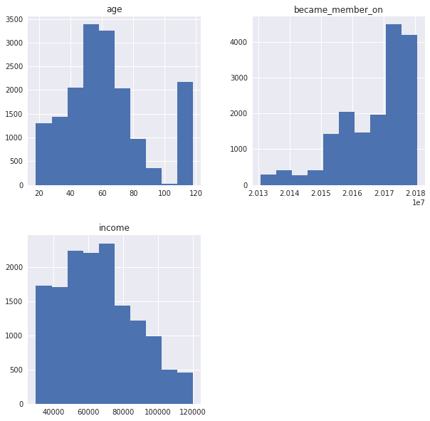

```python
profile.hist(figsize=(10,10));
```

```python
profile['gender'].unique()
```

```
array([None, 'F', 'M', 'O'], dtype=object)
```

```python
gender=profile.gender.value_counts()
gender
```

```
M    8484
F    6129
O     212
Name: gender, dtype: int64
```

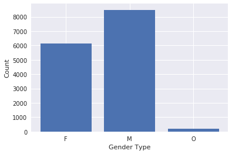

```python
profile_gender_counts = profile.gender.value_counts()
x = ['M','F','O']
data = profile_gender_counts
plt.bar(x,height = data);
xlocs, xlabs = plt.xticks()

plt.xlabel('Gender Type');
plt.ylabel('Count');
```

```python
# is any missing values across columns
profile.isnull().sum()
```

```
age                    0
became_member_on       0
gender              2175
id                     0
income              2175
dtype: int64
```

### transcript

```python
transcript.head()
#   event  (str)             - record description (ie transaction, offer received, offer viewed, etc.)
#   person (str)             - customer id
#   time   (int)             - time in hours since start of test. The data begins at time t=0
#   value  (dict of strings) - either an offer id or transaction amount depending on the record
```

|  | event | person | time | value |
| --- | --- | --- | --- | --- |
| 0 | offer received | 78afa995795e4d85b5d9ceeca43f5fef | 0 | {'offer id': '9b98b8c7a33c4b65b9aebfe6a799e6d9'} |
| 1 | offer received | a03223e636434f42ac4c3df47e8bac43 | 0 | {'offer id': '0b1e1539f2cc45b7b9fa7c272da2e1d7'} |
| 2 | offer received | e2127556f4f64592b11af22de27a7932 | 0 | {'offer id': '2906b810c7d4411798c6938adc9daaa5'} |
| 3 | offer received | 8ec6ce2a7e7949b1bf142def7d0e0586 | 0 | {'offer id': 'fafdcd668e3743c1bb461111dcafc2a4'} |
| 4 | offer received | 68617ca6246f4fbc85e91a2a49552598 | 0 | {'offer id': '4d5c57ea9a6940dd891ad53e9dbe8da0'} |

```python
transcript.info()
```

```
<class 'pandas.core.frame.DataFrame'>
RangeIndex: 306534 entries, 0 to 306533
Data columns (total 4 columns):
event     306534 non-null object
person    306534 non-null object
time      306534 non-null int64
value     306534 non-null object
dtypes: int64(1), object(3)
memory usage: 9.4+ MB
```

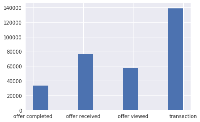

```python
# checking the count of each event type
x=transcript.event
x.hist();
```

```python
transcript.describe()
```

|  | time |
| --- | --- |
| count | 306534.000000 |
| mean | 366.382940 |
| std | 200.326314 |
| min | 0.000000 |
| 25% | 186.000000 |
| 50% | 408.000000 |
| 75% | 528.000000 |
| max | 714.000000 |

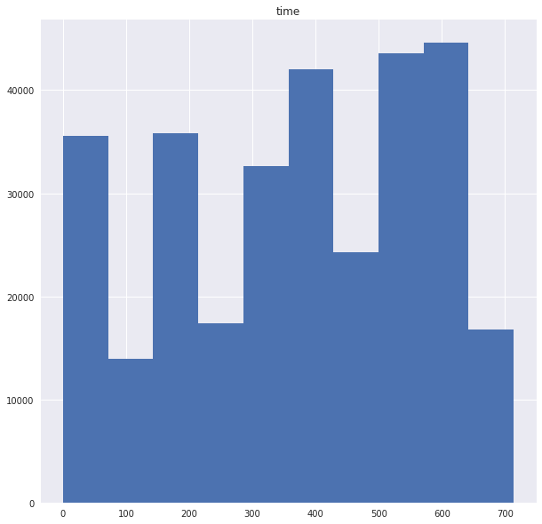

```python
transcript.hist(figsize=(10,10));
```

```python
transcript[['person','value']][transcript['event']=='transaction'].head()
```

|  | person | value |
| --- | --- | --- |
| 12654 | 02c083884c7d45b39cc68e1314fec56c | {'amount': 0.8300000000000001} |
| 12657 | 9fa9ae8f57894cc9a3b8a9bbe0fc1b2f | {'amount': 34.56} |
| 12659 | 54890f68699049c2a04d415abc25e717 | {'amount': 13.23} |
| 12670 | b2f1cd155b864803ad8334cdf13c4bd2 | {'amount': 19.51} |
| 12671 | fe97aa22dd3e48c8b143116a8403dd52 | {'amount': 18.97} |

```python
transcript[['value']][transcript['event']=='offer received'].head()
```

|  | value |
| --- | --- |
| 0 | {'offer id': '9b98b8c7a33c4b65b9aebfe6a799e6d9'} |
| 1 | {'offer id': '0b1e1539f2cc45b7b9fa7c272da2e1d7'} |
| 2 | {'offer id': '2906b810c7d4411798c6938adc9daaa5'} |
| 3 | {'offer id': 'fafdcd668e3743c1bb461111dcafc2a4'} |
| 4 | {'offer id': '4d5c57ea9a6940dd891ad53e9dbe8da0'} |

```python
transcript[['value']][transcript['event']=='offer viewed'].head()
```

|  | value |
| --- | --- |
| 12650 | {'offer id': 'f19421c1d4aa40978ebb69ca19b0e20d'} |
| 12651 | {'offer id': '5a8bc65990b245e5a138643cd4eb9837'} |
| 12652 | {'offer id': '4d5c57ea9a6940dd891ad53e9dbe8da0'} |
| 12653 | {'offer id': 'ae264e3637204a6fb9bb56bc8210ddfd'} |
| 12655 | {'offer id': '5a8bc65990b245e5a138643cd4eb9837'} |

```python
transcript[['value']][transcript['event']=='offer completed'].head()
```

|  | value |
| --- | --- |
| 12658 | {'offer_id': '2906b810c7d4411798c6938adc9daaa5... |
| 12672 | {'offer_id': 'fafdcd668e3743c1bb461111dcafc2a4... |
| 12679 | {'offer_id': '9b98b8c7a33c4b65b9aebfe6a799e6d9... |
| 12692 | {'offer_id': 'ae264e3637204a6fb9bb56bc8210ddfd... |
| 12697 | {'offer_id': '4d5c57ea9a6940dd891ad53e9dbe8da0... |

### Problem Statement and Metrics

#### -What is the most gender and age ?

#### -What is the most registration members year ?

#### -What is the most event in gender and age ?

#### -What is the most viewed offer count in difficulty, duration, offer_type and reward ?

#### -What is the most complet offer count in difficulty, duration, offer_type and reward ?

#### -What is the most transcript in gender ,age and registration members for each year ?

#### -What is the most offer type each age ?

### After Predict

#### -What is the most gender and age in 2018 year ?

#### -What is the most offer type of gender in 2018 year ?

#### -What is the most offer type age in 2018 year ?

### Data Preprocessing and Cleaning

#### Portfolio

-extract data into new columns from channels,offer_type column with iterable values

-add offer name cloumn

-rename id to offer_id

#### profile

-extract age is equal 118

-division age 10

-remove age up 90 years old

-remve gender type 'O'

-convert gender F to 0 and M To 1 and convert to int

-convert became_member_on to date ,get year from date ,rename to reg_year and convert to int

-division income 10000 and convert to int

-rename id to person_id

#### transcript

-extract data into new columns from event

-extract data into new columns from value to amount,offer_id and reward

-time is hours division 24 to convert dates

-rename person to person_id

-rename value_offer_id to offer_id

#### general

-convert all number to int

-join all datasets

-rename some columns

-drop some columns

### Implementation

#### Convert columns values to columns zero and one for Analysis and ML

```python
# Create function extract data into new columns from a column with iterable values like lists or dictionaries.
def extract_from_iterable_col(df, old_col, drop_old_col=False, unique_values=None, unique_keys=None):

    '''
    Extract data into new columns from a column with iterable values like lists or dictionaries.
    If extracting from dictionaries, the new column names will be the dictionary keys and the
    values will be dictionary values. If extracting from lists, one-hot encode the list values.

    Args:
        (1) df (Pandas dataframe) - data containing a column with iterable values
        (2) old_col (str) - name of column to extract data from
        (3) drop_old_col (bool) - whether or not to drop the old column after extracting data from it
        (4) unique_values (list[str]) - pass in unique values if data type of column is list *
        (5) unique_values (list[str]) - pass in unique keys if data type of column is dictionary *
        * Pass in arg (4) for a list column or arg (5) for a dictionary column

    Returns:
        Same data with new columns extracted from the old column (Pandas dataframe).
    '''


    df = df.copy()

    if unique_keys is not None: # for dicts
        for k in unique_keys:
            if ' ' not in k: # to skip duplicate key with space
                df[(old_col+'_'+k).replace(' ', '_')]= df[old_col].apply(lambda d: d[k] if k in d # get dict val
                                          else (d[k.replace('_', ' ')] if k.replace('_', ' ') in d # for duplicate key with space
                                                else np.NaN)) # val is nan if key is not in dict

    elif unique_values is not None: # for lists
        for v in unique_values:
            new_col = df[old_col].apply(lambda lst: int(v in lst)) # 1 if val is in list else 0
            if np.var(new_col): # if new col is not constant
                df[(old_col+'_'+v).replace(' ', '_')] = new_col # add new col

    if drop_old_col:
        df.drop(old_col, axis=1, inplace=True)

    return df
```

#### portfolio

```python
# add titel name for every offer
for row in range(10):
    portfolio.at[row, 'offer_name']=row

portfolio['offer_name']=portfolio['offer_name'].astype(int)
portfolio.head(10)
```

|  | channels | difficulty | duration | id | offer_type | reward | offer_name |
| --- | --- | --- | --- | --- | --- | --- | --- |
| 0 | [email, mobile, social] | 10 | 7 | ae264e3637204a6fb9bb56bc8210ddfd | bogo | 10 | 0 |
| 1 | [web, email, mobile, social] | 10 | 5 | 4d5c57ea9a6940dd891ad53e9dbe8da0 | bogo | 10 | 1 |
| 2 | [web, email, mobile] | 0 | 4 | 3f207df678b143eea3cee63160fa8bed | informational | 0 | 2 |
| 3 | [web, email, mobile] | 5 | 7 | 9b98b8c7a33c4b65b9aebfe6a799e6d9 | bogo | 5 | 3 |
| 4 | [web, email] | 20 | 10 | 0b1e1539f2cc45b7b9fa7c272da2e1d7 | discount | 5 | 4 |
| 5 | [web, email, mobile, social] | 7 | 7 | 2298d6c36e964ae4a3e7e9706d1fb8c2 | discount | 3 | 5 |
| 6 | [web, email, mobile, social] | 10 | 10 | fafdcd668e3743c1bb461111dcafc2a4 | discount | 2 | 6 |
| 7 | [email, mobile, social] | 0 | 3 | 5a8bc65990b245e5a138643cd4eb9837 | informational | 0 | 7 |
| 8 | [web, email, mobile, social] | 5 | 5 | f19421c1d4aa40978ebb69ca19b0e20d | bogo | 5 | 8 |
| 9 | [web, email, mobile] | 10 | 7 | 2906b810c7d4411798c6938adc9daaa5 | discount | 2 | 9 |

```python
# Extract list values from offer_type data
portfolio['offer_type'].value_counts()
```

```
bogo             4
discount         4
informational    2
Name: offer_type, dtype: int64
```

```python
# Extract list values from offer_type data
portfolio = extract_from_iterable_col(portfolio, 'offer_type', unique_values=['bogo', 'informational', 'discount'])
```

```python
# Extract list values from offer_type data
portfolio = extract_from_iterable_col(portfolio, 'channels', unique_values=['web', 'email', 'mobile', 'social'],drop_old_col=True)
```

```python
# rename column id to offer_id
portfolio = portfolio.rename(columns = {'id':'offer_id'})
portfolio.head()
```

|  | difficulty | duration | offer_id | offer_type | reward | offer_name | offer_type_bogo | offer_type_informational | offer_type_discount | channels_web | channels_mobile | channels_social |
| --- | --- | --- | --- | --- | --- | --- | --- | --- | --- | --- | --- | --- |
| 0 | 10 | 7 | ae264e3637204a6fb9bb56bc8210ddfd | bogo | 10 | 0 | 1 | 0 | 0 | 0 | 1 | 1 |
| 1 | 10 | 5 | 4d5c57ea9a6940dd891ad53e9dbe8da0 | bogo | 10 | 1 | 1 | 0 | 0 | 1 | 1 | 1 |
| 2 | 0 | 4 | 3f207df678b143eea3cee63160fa8bed | informational | 0 | 2 | 0 | 1 | 0 | 1 | 1 | 0 |
| 3 | 5 | 7 | 9b98b8c7a33c4b65b9aebfe6a799e6d9 | bogo | 5 | 3 | 1 | 0 | 0 | 1 | 1 | 0 |
| 4 | 20 | 10 | 0b1e1539f2cc45b7b9fa7c272da2e1d7 | discount | 5 | 4 | 0 | 0 | 1 | 1 | 0 | 0 |

#### profile

###### Missing data for better analysis.

```python
# creating a dataframe with only the customers with age = 118
# this data frame will include the coressponding gender and income columns to the customers with age = 118
df_118 = profile[['gender','income','age']][profile['age']==118]
df_118.info()
```

```
<class 'pandas.core.frame.DataFrame'>
Int64Index: 2175 entries, 0 to 16994
Data columns (total 3 columns):
gender    0 non-null object
income    0 non-null float64
age       2175 non-null int64
dtypes: float64(1), int64(1), object(1)
memory usage: 68.0+ KB
```

#### We have 2175 customer's without any info for gender,income and age

```python
# set age group
profile['age']=(((profile['age']/10).astype(int))*10).astype(int)
```

```python
# remove missing data for profile "age = 118" or age up 90 years.
profile=profile[profile['age']<100]
```

```python
profile['age'].value_counts()
```

```
50    3541
60    2991
40    2309
70    1782
30    1526
20    1369
80     831
90     254
10     205
Name: age, dtype: int64
```

```python
# remove data for profile "gender = 'O'".
profile=profile[profile['gender']!='O']
profile['gender'].value_counts()
```

```
M    8482
F    6115
Name: gender, dtype: int64
```

```python
# replace gender one for man zero for woman
profile['gender']=profile['gender'].replace(['M'],'1').replace(['F'],'0').astype(int)
profile['gender'].value_counts()
```

```
1    8482
0    6115
Name: gender, dtype: int64
```

```python
# get year for became_member_on
profile['became_member_on'] = pd.to_datetime(profile['became_member_on'], format='%Y%m%d')
# set reg_year from became_member_on column that has the year which customers become members

# What is the most complet
profile['reg_year'] = profile['became_member_on'].dt.year
# drop became_member_on column
profile=profile.drop(['became_member_on'], axis=1)

profile.head()
```

|  | age | gender | id | income | reg_year |
| --- | --- | --- | --- | --- | --- |
| 1 | 50 | 0 | 0610b486422d4921ae7d2bf64640c50b | 112000.0 | 2017 |
| 3 | 70 | 0 | 78afa995795e4d85b5d9ceeca43f5fef | 100000.0 | 2017 |
| 5 | 60 | 1 | e2127556f4f64592b11af22de27a7932 | 70000.0 | 2018 |
| 8 | 60 | 1 | 389bc3fa690240e798340f5a15918d5c | 53000.0 | 2018 |
| 12 | 50 | 1 | 2eeac8d8feae4a8cad5a6af0499a211d | 51000.0 | 2017 |

```python
profile['reg_year'].value_counts()
```

```
2017    5501
2018    3611
2016    2992
2015    1564
2014     658
2013     271
Name: reg_year, dtype: int64
```

```python
profile['income']=(profile['income']/10000).astype(int)
```

```python
# rename column id to person_id
profile = profile.rename(columns = {'id':'person_id'})
profile.head()
```

|  | age | gender | person_id | income | reg_year |
| --- | --- | --- | --- | --- | --- |
| 1 | 50 | 0 | 0610b486422d4921ae7d2bf64640c50b | 11 | 2017 |
| 3 | 70 | 0 | 78afa995795e4d85b5d9ceeca43f5fef | 10 | 2017 |
| 5 | 60 | 1 | e2127556f4f64592b11af22de27a7932 | 7 | 2018 |
| 8 | 60 | 1 | 389bc3fa690240e798340f5a15918d5c | 5 | 2018 |
| 12 | 50 | 1 | 2eeac8d8feae4a8cad5a6af0499a211d | 5 | 2017 |

```python
profile.info()
```

```
<class 'pandas.core.frame.DataFrame'>
Int64Index: 14597 entries, 1 to 16999
Data columns (total 5 columns):
age          14597 non-null int64
gender       14597 non-null int64
person_id    14597 non-null object
income       14597 non-null int64
reg_year     14597 non-null int64
dtypes: int64(4), object(1)
memory usage: 684.2+ KB
```

#### transcript

```python
# extract data into new columns from events
transcript = extract_from_iterable_col(transcript, 'event', unique_values=['transaction','offer received','offer viewed','offer completed'])
transcript.head()
```

|  | event | person | time | value | event_transaction | event_offer_received | event_offer_viewed | event_offer_completed |
| --- | --- | --- | --- | --- | --- | --- | --- | --- |
| 0 | offer received | 78afa995795e4d85b5d9ceeca43f5fef | 0 | {'offer id': '9b98b8c7a33c4b65b9aebfe6a799e6d9'} | 0 | 1 | 0 | 0 |
| 1 | offer received | a03223e636434f42ac4c3df47e8bac43 | 0 | {'offer id': '0b1e1539f2cc45b7b9fa7c272da2e1d7'} | 0 | 1 | 0 | 0 |
| 2 | offer received | e2127556f4f64592b11af22de27a7932 | 0 | {'offer id': '2906b810c7d4411798c6938adc9daaa5'} | 0 | 1 | 0 | 0 |
| 3 | offer received | 8ec6ce2a7e7949b1bf142def7d0e0586 | 0 | {'offer id': 'fafdcd668e3743c1bb461111dcafc2a4'} | 0 | 1 | 0 | 0 |
| 4 | offer received | 68617ca6246f4fbc85e91a2a49552598 | 0 | {'offer id': '4d5c57ea9a6940dd891ad53e9dbe8da0'} | 0 | 1 | 0 | 0 |

```python
# Extract dictionary values from value data
transcript = extract_from_iterable_col(transcript, 'value', unique_keys=['amount', 'offer id', 'offer_id', 'reward'],drop_old_col=True)
transcript.head()
```

|  | event | person | time | event_transaction | event_offer_received | event_offer_viewed | event_offer_completed | value_amount | value_offer_id | value_reward |
| --- | --- | --- | --- | --- | --- | --- | --- | --- | --- | --- |
| 0 | offer received | 78afa995795e4d85b5d9ceeca43f5fef | 0 | 0 | 1 | 0 | 0 | NaN | 9b98b8c7a33c4b65b9aebfe6a799e6d9 | NaN |
| 1 | offer received | a03223e636434f42ac4c3df47e8bac43 | 0 | 0 | 1 | 0 | 0 | NaN | 0b1e1539f2cc45b7b9fa7c272da2e1d7 | NaN |
| 2 | offer received | e2127556f4f64592b11af22de27a7932 | 0 | 0 | 1 | 0 | 0 | NaN | 2906b810c7d4411798c6938adc9daaa5 | NaN |
| 3 | offer received | 8ec6ce2a7e7949b1bf142def7d0e0586 | 0 | 0 | 1 | 0 | 0 | NaN | fafdcd668e3743c1bb461111dcafc2a4 | NaN |
| 4 | offer received | 68617ca6246f4fbc85e91a2a49552598 | 0 | 0 | 1 | 0 | 0 | NaN | 4d5c57ea9a6940dd891ad53e9dbe8da0 | NaN |

```python
x=transcript.groupby(['value_offer_id','event'])['time'].count().reset_index(name ='total')
x=pd.pivot_table(x, index=["value_offer_id"], columns=["event"], values=["total"], aggfunc="sum")
x.head(10)
```

| event value_offer_id | total offer completed | total offer received | total offer viewed |
| --- | --- | --- | --- |
| 0b1e1539f2cc45b7b9fa7c272da2e1d7 | 3420.0 | 7668.0 | 2663.0 |
| 2298d6c36e964ae4a3e7e9706d1fb8c2 | 5156.0 | 7646.0 | 7337.0 |
| 2906b810c7d4411798c6938adc9daaa5 | 4017.0 | 7632.0 | 4118.0 |
| 3f207df678b143eea3cee63160fa8bed | NaN | 7617.0 | 4144.0 |
| 4d5c57ea9a6940dd891ad53e9dbe8da0 | 3331.0 | 7593.0 | 7298.0 |
| 5a8bc65990b245e5a138643cd4eb9837 | NaN | 7618.0 | 6687.0 |
| 9b98b8c7a33c4b65b9aebfe6a799e6d9 | 4354.0 | 7677.0 | 4171.0 |
| ae264e3637204a6fb9bb56bc8210ddfd | 3688.0 | 7658.0 | 6716.0 |
| f19421c1d4aa40978ebb69ca19b0e20d | 4296.0 | 7571.0 | 7264.0 |
| fafdcd668e3743c1bb461111dcafc2a4 | 5317.0 | 7597.0 | 7327.0 |

#### same offer not completed [3f207df678b143eea3cee63160fa8bed - 5a8bc65990b245e5a138643cd4eb9837]

#### same offer completed more than viewed [0b1e1539f2cc45b7b9fa7c272da2e1d7 - 9b98b8c7a33c4b65b9aebfe6a799e6d9]

```python
# convert time from hours to dates by division 24
transcript['time']=transcript['time']/24
```

```python
# fill null values to 0
transcript=transcript.fillna(0)
```

```python
# rename columns
transcript = transcript.rename(columns = {'person':'person_id'})
transcript = transcript.rename(columns = {'value_offer_id':'offer_id'})
transcript.head()
```

|  | event | person_id | time | event_transaction | event_offer_received | event_offer_viewed | event_offer_completed | value_amount | offer_id | value_reward |
| --- | --- | --- | --- | --- | --- | --- | --- | --- | --- | --- |
| 0 | offer received | 78afa995795e4d85b5d9ceeca43f5fef | 0.0 | 0 | 1 | 0 | 0 | 0.0 | 9b98b8c7a33c4b65b9aebfe6a799e6d9 | 0.0 |
| 1 | offer received | a03223e636434f42ac4c3df47e8bac43 | 0.0 | 0 | 1 | 0 | 0 | 0.0 | 0b1e1539f2cc45b7b9fa7c272da2e1d7 | 0.0 |
| 2 | offer received | e2127556f4f64592b11af22de27a7932 | 0.0 | 0 | 1 | 0 | 0 | 0.0 | 2906b810c7d4411798c6938adc9daaa5 | 0.0 |
| 3 | offer received | 8ec6ce2a7e7949b1bf142def7d0e0586 | 0.0 | 0 | 1 | 0 | 0 | 0.0 | fafdcd668e3743c1bb461111dcafc2a4 | 0.0 |
| 4 | offer received | 68617ca6246f4fbc85e91a2a49552598 | 0.0 | 0 | 1 | 0 | 0 | 0.0 | 4d5c57ea9a6940dd891ad53e9dbe8da0 | 0.0 |

```python
transcript['event_offer_completed'].value_counts()
```

```
0    272955
1     33579
Name: event_offer_completed, dtype: int64
```

```python
transcript['event_offer_viewed'].value_counts()
```

```
0    248809
1     57725
Name: event_offer_viewed, dtype: int64
```

##### Merging the three clean datasets (Portfolio, Profile and Transaction ) into ONE Master Clean Dataset

```python
transcript_profile_df= pd.merge(transcript, profile, on='person_id', how='inner')
```

```python
inner_join_df= pd.merge(transcript_profile_df,portfolio, on='offer_id', how='inner')
```

```python
inner_join_df=inner_join_df.drop(['person_id'], axis=1)
inner_join_df=inner_join_df.drop(['offer_id'], axis=1)
```

```python
inner_join_df.head()
```

|  | event | time | event_transaction | event_offer_received | event_offer_viewed | event_offer_completed | value_amount | value_reward | age | gender | ... | duration | offer_type | reward | offer_name | offer_type_bogo | offer_type_informational | offer_type_discount | channels_web | channels_mobile | channels_social |
| --- | --- | --- | --- | --- | --- | --- | --- | --- | --- | --- | --- | --- | --- | --- | --- | --- | --- | --- | --- | --- | --- |
| 0 | offer received | 0.00 | 0 | 1 | 0 | 0 | 0.0 | 0.0 | 70 | 0 | ... | 7 | bogo | 5 | 3 | 1 | 0 | 0 | 1 | 1 | 0 |
| 1 | offer viewed | 0.25 | 0 | 0 | 1 | 0 | 0.0 | 0.0 | 70 | 0 | ... | 7 | bogo | 5 | 3 | 1 | 0 | 0 | 1 | 1 | 0 |
| 2 | offer completed | 5.50 | 0 | 0 | 0 | 1 | 0.0 | 5.0 | 70 | 0 | ... | 7 | bogo | 5 | 3 | 1 | 0 | 0 | 1 | 1 | 0 |
| 3 | offer received | 17.00 | 0 | 1 | 0 | 0 | 0.0 | 0.0 | 60 | 1 | ... | 7 | bogo | 5 | 3 | 1 | 0 | 0 | 1 | 1 | 0 |
| 4 | offer viewed | 17.50 | 0 | 0 | 1 | 0 | 0.0 | 0.0 | 60 | 1 | ... | 7 | bogo | 5 | 3 | 1 | 0 | 0 | 1 | 1 | 0 |

5 rows × 23 columns

```python
inner_join_df.info()
```

```
<class 'pandas.core.frame.DataFrame'>
Int64Index: 146446 entries, 0 to 146445
Data columns (total 23 columns):
event                       146446 non-null object
time                        146446 non-null float64
event_transaction           146446 non-null int64
event_offer_received        146446 non-null int64
event_offer_viewed          146446 non-null int64
event_offer_completed       146446 non-null int64
value_amount                146446 non-null float64
value_reward                146446 non-null float64
age                         146446 non-null int64
gender                      146446 non-null int64
income                      146446 non-null int64
reg_year                    146446 non-null int64
difficulty                  146446 non-null int64
duration                    146446 non-null int64
offer_type                  146446 non-null object
reward                      146446 non-null int64
offer_name                  146446 non-null int64
offer_type_bogo             146446 non-null int64
offer_type_informational    146446 non-null int64
offer_type_discount         146446 non-null int64
channels_web                146446 non-null int64
channels_mobile             146446 non-null int64
channels_social             146446 non-null int64
dtypes: float64(3), int64(18), object(2)
memory usage: 26.8+ MB
```

```python
inner_join_df.describe()
```

|  | time | event_transaction | event_offer_received | event_offer_viewed | event_offer_completed | value_amount | value_reward | age | gender | income | ... | difficulty | duration | reward | offer_name | offer_type_bogo | offer_type_informational | offer_type_discount | channels_web | channels_mobile | channels_social |
| --- | --- | --- | --- | --- | --- | --- | --- | --- | --- | --- | --- | --- | --- | --- | --- | --- | --- | --- | --- | --- | --- |
| count | 146446.000000 | 146446.0 | 146446.000000 | 146446.000000 | 146446.000000 | 146446.0 | 146446.000000 | 146446.000000 | 146446.000000 | 146446.000000 | ... | 146446.000000 | 146446.000000 | 146446.000000 | 146446.000000 | 146446.000000 | 146446.000000 | 146446.000000 | 146446.000000 | 146446.000000 | 146446.000000 |
| mean | 14.779045 | 0.0 | 0.447359 | 0.334813 | 0.217828 | 0.0 | 1.077769 | 50.225749 | 0.565915 | 6.205748 | ... | 7.890048 | 6.624380 | 4.445065 | 4.544938 | 0.429237 | 0.152131 | 0.418632 | 0.806707 | 0.917376 | 0.658987 |
| std | 8.262043 | 0.0 | 0.497223 | 0.471927 | 0.412771 | 0.0 | 2.451707 | 17.406954 | 0.495638 | 2.142927 | ... | 5.037318 | 2.132563 | 3.373735 | 2.888554 | 0.494969 | 0.359149 | 0.493337 | 0.394882 | 0.275314 | 0.474051 |
| min | 0.000000 | 0.0 | 0.000000 | 0.000000 | 0.000000 | 0.0 | 0.000000 | 10.000000 | 0.000000 | 3.000000 | ... | 0.000000 | 3.000000 | 0.000000 | 0.000000 | 0.000000 | 0.000000 | 0.000000 | 0.000000 | 0.000000 | 0.000000 |
| 25% | 7.000000 | 0.0 | 0.000000 | 0.000000 | 0.000000 | 0.0 | 0.000000 | 40.000000 | 0.000000 | 5.000000 | ... | 5.000000 | 5.000000 | 2.000000 | 2.000000 | 0.000000 | 0.000000 | 0.000000 | 1.000000 | 1.000000 | 0.000000 |
| 50% | 17.000000 | 0.0 | 0.000000 | 0.000000 | 0.000000 | 0.0 | 0.000000 | 50.000000 | 1.000000 | 6.000000 | ... | 10.000000 | 7.000000 | 5.000000 | 5.000000 | 0.000000 | 0.000000 | 0.000000 | 1.000000 | 1.000000 | 1.000000 |
| 75% | 21.250000 | 0.0 | 1.000000 | 1.000000 | 0.000000 | 0.0 | 0.000000 | 60.000000 | 1.000000 | 8.000000 | ... | 10.000000 | 7.000000 | 5.000000 | 7.000000 | 1.000000 | 0.000000 | 1.000000 | 1.000000 | 1.000000 | 1.000000 |
| max | 29.750000 | 0.0 | 1.000000 | 1.000000 | 1.000000 | 0.0 | 10.000000 | 90.000000 | 1.000000 | 12.000000 | ... | 20.000000 | 10.000000 | 10.000000 | 9.000000 | 1.000000 | 1.000000 | 1.000000 | 1.000000 | 1.000000 | 1.000000 |

8 rows × 21 columns

### Quick Data Analysis

#### What is the most gender and age ?

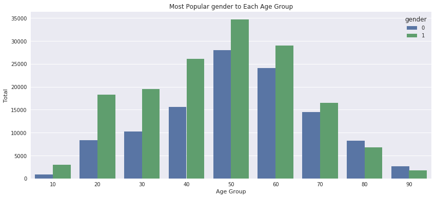

```python
plt.figure(figsize=(14, 6))
g = sns.countplot(x="age", hue="gender", data=transcript_profile_df)
plt.title('Most Popular gender to Each Age Group')
plt.ylabel('Total')
plt.xlabel('Age Group')
plt.xticks(rotation = 0)
plt.legend(title='gender')
plt.show();
```

##### What is the most registration members year ?

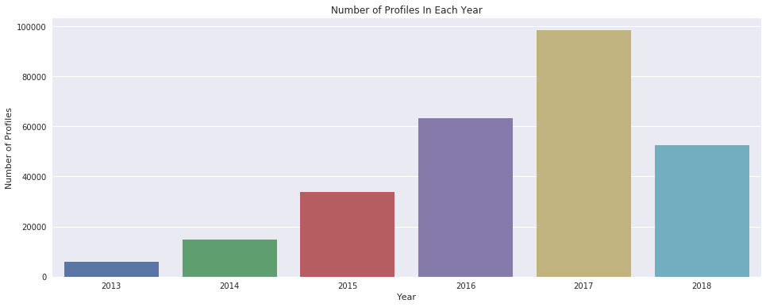

```python
plt.figure(figsize=(16, 6))
sns.countplot(transcript_profile_df['reg_year'])
plt.title('Number of Profiles In Each Year')
plt.ylabel('Number of Profiles')
plt.xlabel('Year')
plt.xticks()
plt.show();
```

##### What is the most event in gender ?

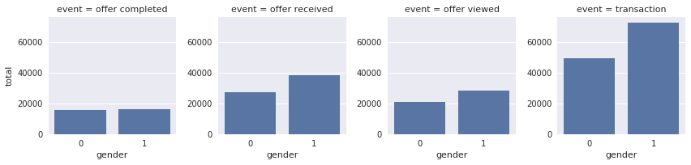

```python
xx=transcript_profile_df.groupby(['event','gender'])['time'].count().reset_index(name ='total')
g = sns.FacetGrid(xx, col="event")
g.map(sns.barplot, "gender", "total")
```

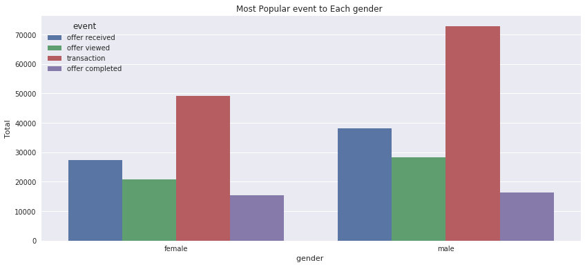

```python
plt.figure(figsize=(14, 6))
g = sns.countplot(x="gender", hue="event", data=transcript_profile_df)
plt.title('Most Popular event to Each gender ')
plt.ylabel('Total')
plt.xlabel('gender ')
xlabels = ['female','male']
g.set_xticklabels(xlabels)
plt.xticks(rotation = 0)
plt.legend(title='event')
plt.show();
```

#### What is the most event in age ?

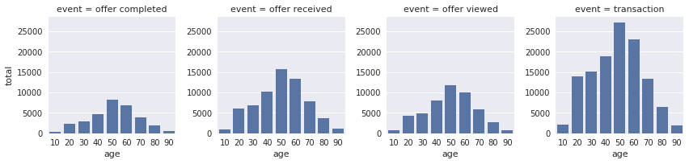

```python
xx=transcript_profile_df.groupby(['event','age'])['time'].count().reset_index(name ='total')
g = sns.FacetGrid(xx, col="event")
g.map(sns.barplot, "age", "total")
```

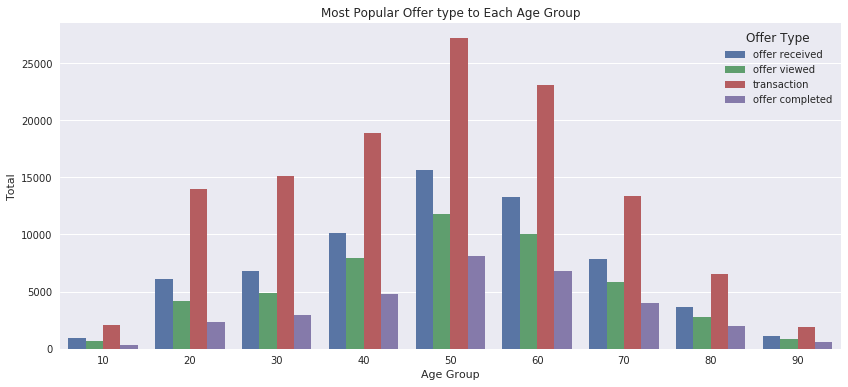

```python
plt.figure(figsize=(14, 6))
g = sns.countplot(x="age", hue="event", data=transcript_profile_df)
plt.title('Most Popular Offer type to Each Age Group')
plt.ylabel('Total')
plt.xlabel('Age Group')
plt.xticks(rotation = 0)
plt.legend(title='Offer Type')
plt.show();
```

#### What is the most viewed offer count in difficulty ?

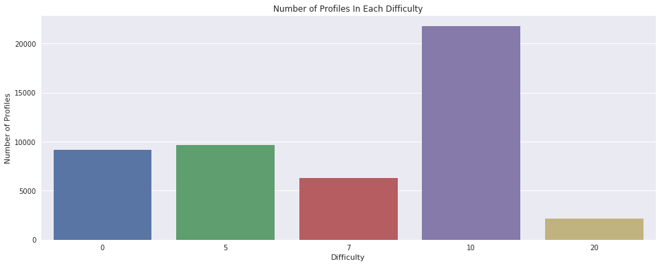

```python
xx=inner_join_df[inner_join_df["event"]=="offer viewed"]
plt.figure(figsize=(16, 6))
sns.countplot(xx['difficulty'])
plt.title('Number of Profiles In Each Difficulty')
plt.ylabel('Number of Profiles')
plt.xlabel('Difficulty')
plt.xticks()
plt.show();
```

#### What is the most viewed offer count in duration ?

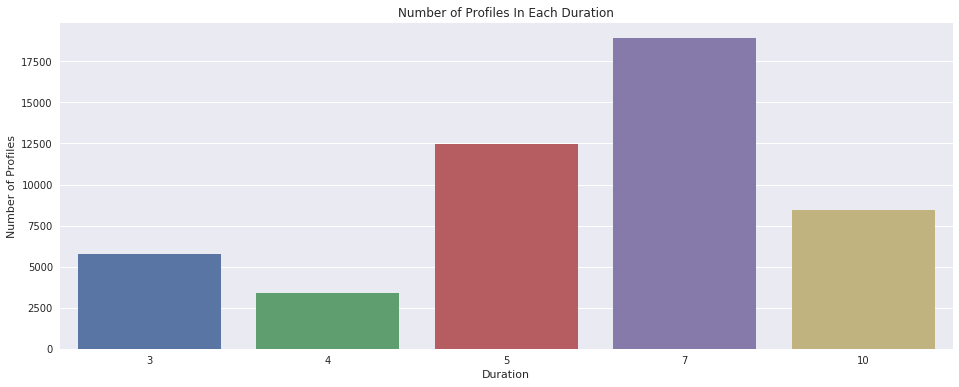

```python
xx=inner_join_df[inner_join_df["event"]=="offer viewed"]
plt.figure(figsize=(16, 6))
sns.countplot(xx['duration'])
plt.title('Number of Profiles In Each Duration')
plt.ylabel('Number of Profiles')
plt.xlabel('Duration')
plt.xticks()
plt.show();
```

#### What is the most viewed offer count in offer_type ?

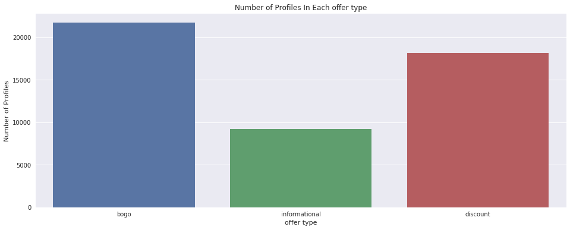

```python
xx=inner_join_df[inner_join_df["event"]=="offer viewed"]
plt.figure(figsize=(16, 6))
sns.countplot(xx['offer_type'])
plt.title('Number of Profiles In Each offer type')
plt.ylabel('Number of Profiles')
plt.xlabel('offer type')
plt.xticks()
plt.show();
```

#### What is the most viewed offer count in reward ?

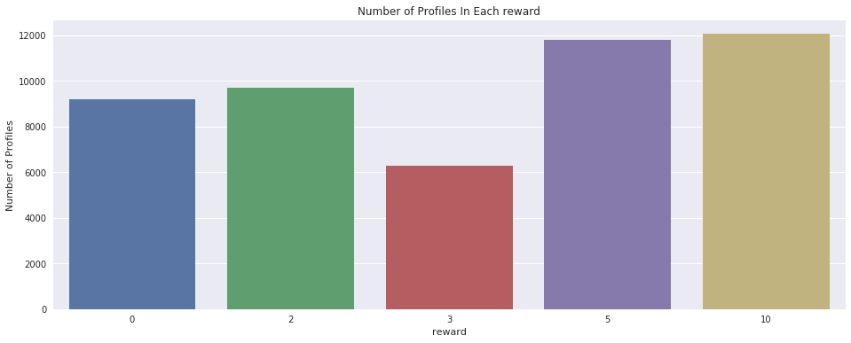

```python
xx=inner_join_df[inner_join_df["event"]=="offer viewed"]
plt.figure(figsize=(16, 6))
sns.countplot(xx['reward'])
plt.title('Number of Profiles In Each reward')
plt.ylabel('Number of Profiles')
plt.xlabel('reward')
plt.xticks()
plt.show();
```

#### What is the most completed offer count in difficulty ?

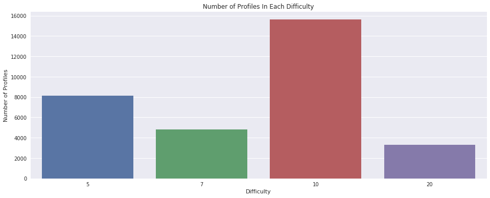

```python
xx=inner_join_df[inner_join_df["event"]=="offer completed"]
plt.figure(figsize=(16, 6))
sns.countplot(xx['difficulty'])
plt.title('Number of Profiles In Each Difficulty')
plt.ylabel('Number of Profiles')
plt.xlabel('Difficulty')
plt.xticks()
plt.show();
```

#### What is the most completed offer count in duration ?

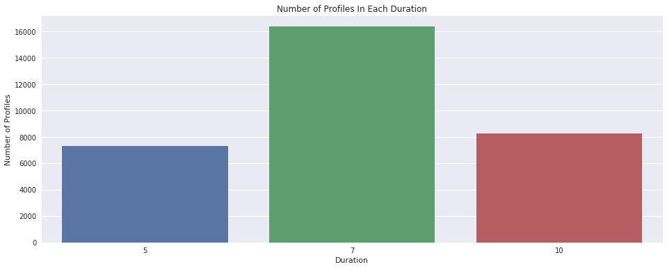

```python
xx=inner_join_df[inner_join_df["event"]=="offer completed"]
plt.figure(figsize=(16, 6))
sns.countplot(xx['duration'])
plt.title('Number of Profiles In Each Duration')
plt.ylabel('Number of Profiles')
plt.xlabel('Duration')
plt.xticks()
plt.show();
```

#### What is the most completed offer count in offer_type ?

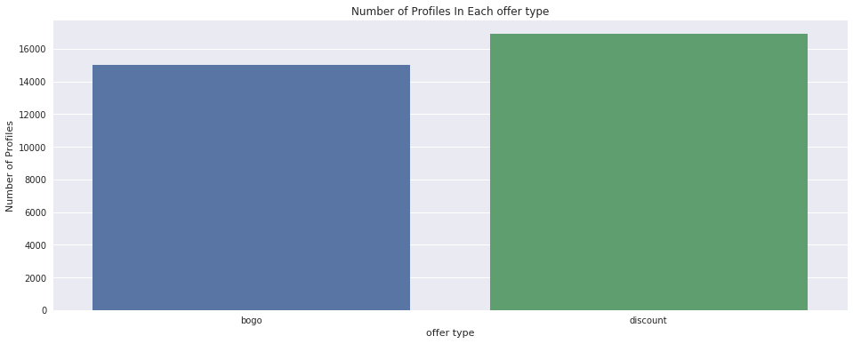

```python
xx=inner_join_df[inner_join_df["event"]=="offer completed"]
plt.figure(figsize=(16, 6))
sns.countplot(xx['offer_type'])
plt.title('Number of Profiles In Each offer type')
plt.ylabel('Number of Profiles')
plt.xlabel('offer type')
plt.xticks()
plt.show();
```

#### What is the most completed offer count in reward ?

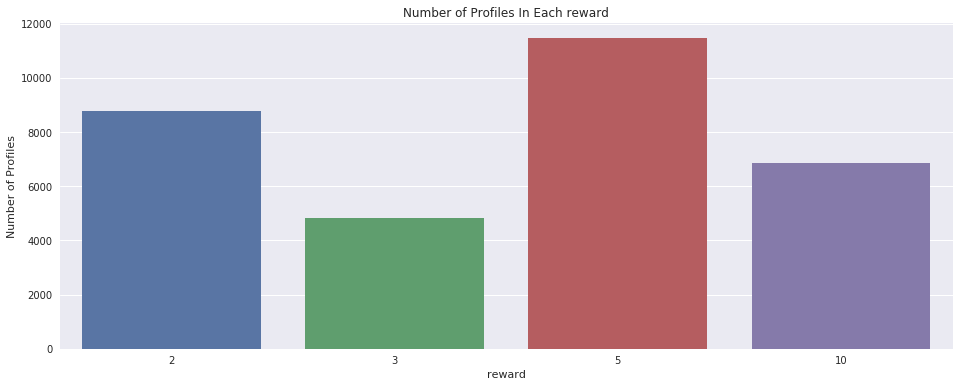

```python
xx=inner_join_df[inner_join_df["event"]=="offer completed"]
plt.figure(figsize=(16, 6))
sns.countplot(xx['reward'])
plt.title('Number of Profiles In Each reward')
plt.ylabel('Number of Profiles')
plt.xlabel('reward')
plt.xticks()
plt.show();
```

```python
inner_join_df.info()
```

```
<class 'pandas.core.frame.DataFrame'>
Int64Index: 146446 entries, 0 to 146445
Data columns (total 23 columns):
event                       146446 non-null object
time                        146446 non-null float64
event_transaction           146446 non-null int64
event_offer_received        146446 non-null int64
event_offer_viewed          146446 non-null int64
event_offer_completed       146446 non-null int64
value_amount                146446 non-null float64
value_reward                146446 non-null float64
age                         146446 non-null int64
gender                      146446 non-null int64
income                      146446 non-null int64
reg_year                    146446 non-null int64
difficulty                  146446 non-null int64
duration                    146446 non-null int64
offer_type                  146446 non-null object
reward                      146446 non-null int64
offer_name                  146446 non-null int64
offer_type_bogo             146446 non-null int64
offer_type_informational    146446 non-null int64
offer_type_discount         146446 non-null int64
channels_web                146446 non-null int64
channels_mobile             146446 non-null int64
channels_social             146446 non-null int64
dtypes: float64(3), int64(18), object(2)
memory usage: 26.8+ MB
```

```python
inner_join_df=inner_join_df.drop(['event'], axis=1)
inner_join_df=inner_join_df.drop(['offer_type'], axis=1)
```

### model

```python
from sklearn.model_selection import train_test_split, cross_val_score
from sklearn.linear_model import LogisticRegression
from sklearn.dummy import DummyClassifier
from sklearn.pipeline import Pipeline
from sklearn.model_selection import GridSearchCV
from sklearn.metrics import accuracy_score, confusion_matrix, classification_report
```

```python
label = inner_join_df['event_offer_completed'].copy()
train = inner_join_df.drop(['event_offer_completed'], axis=1)

#Dividing the data into train and test
X_train, X_test, Y_train, Y_test = train_test_split(train, label,test_size=0.2, random_state=0)
X_train.shape, X_test.shape, Y_train.shape, Y_test.shape
```

```
((117156, 20), (29290, 20), (117156,), (29290,))
```

```python
train.head()
```

|  | time | event_transaction | event_offer_received | event_offer_viewed | value_amount | value_reward | age | gender | income | reg_year | difficulty | duration | reward | offer_name | offer_type_bogo | offer_type_informational | offer_type_discount | channels_web | channels_mobile | channels_social |
| --- | --- | --- | --- | --- | --- | --- | --- | --- | --- | --- | --- | --- | --- | --- | --- | --- | --- | --- | --- | --- |
| 0 | 0.00 | 0 | 1 | 0 | 0.0 | 0.0 | 70 | 0 | 10 | 2017 | 5 | 7 | 5 | 3 | 1 | 0 | 0 | 1 | 1 | 0 |
| 1 | 0.25 | 0 | 0 | 1 | 0.0 | 0.0 | 70 | 0 | 10 | 2017 | 5 | 7 | 5 | 3 | 1 | 0 | 0 | 1 | 1 | 0 |
| 2 | 5.50 | 0 | 0 | 0 | 0.0 | 5.0 | 70 | 0 | 10 | 2017 | 5 | 7 | 5 | 3 | 1 | 0 | 0 | 1 | 1 | 0 |
| 3 | 17.00 | 0 | 1 | 0 | 0.0 | 0.0 | 60 | 1 | 7 | 2018 | 5 | 7 | 5 | 3 | 1 | 0 | 0 | 1 | 1 | 0 |
| 4 | 17.50 | 0 | 0 | 1 | 0.0 | 0.0 | 60 | 1 | 7 | 2018 | 5 | 7 | 5 | 3 | 1 | 0 | 0 | 1 | 1 | 0 |

```python
X_train.head()
```

|  | time | event_transaction | event_offer_received | event_offer_viewed | value_amount | value_reward | age | gender | income | reg_year | difficulty | duration | reward | offer_name | offer_type_bogo | offer_type_informational | offer_type_discount | channels_web | channels_mobile | channels_social |
| --- | --- | --- | --- | --- | --- | --- | --- | --- | --- | --- | --- | --- | --- | --- | --- | --- | --- | --- | --- | --- |
| 70405 | 24.00 | 0 | 1 | 0 | 0.0 | 0.0 | 60 | 1 | 4 | 2016 | 10 | 7 | 2 | 9 | 0 | 0 | 1 | 1 | 1 | 0 |
| 28061 | 7.50 | 0 | 0 | 1 | 0.0 | 0.0 | 30 | 0 | 5 | 2013 | 10 | 7 | 10 | 0 | 1 | 0 | 0 | 0 | 1 | 1 |
| 93011 | 25.75 | 0 | 0 | 1 | 0.0 | 0.0 | 60 | 0 | 9 | 2016 | 10 | 10 | 2 | 6 | 0 | 0 | 1 | 1 | 1 | 1 |
| 67154 | 21.75 | 0 | 0 | 0 | 0.0 | 2.0 | 60 | 1 | 8 | 2018 | 10 | 7 | 2 | 9 | 0 | 0 | 1 | 1 | 1 | 0 |
| 46022 | 17.25 | 0 | 0 | 1 | 0.0 | 0.0 | 60 | 1 | 7 | 2015 | 5 | 5 | 5 | 8 | 1 | 0 | 0 | 1 | 1 | 1 |

```python
X_test.head()
```

|  | time | event_transaction | event_offer_received | event_offer_viewed | value_amount | value_reward | age | gender | income | reg_year | difficulty | duration | reward | offer_name | offer_type_bogo | offer_type_informational | offer_type_discount | channels_web | channels_mobile | channels_social |
| --- | --- | --- | --- | --- | --- | --- | --- | --- | --- | --- | --- | --- | --- | --- | --- | --- | --- | --- | --- | --- |
| 57654 | 21.00 | 0 | 1 | 0 | 0.0 | 0.0 | 30 | 1 | 4 | 2018 | 5 | 5 | 5 | 8 | 1 | 0 | 0 | 1 | 1 | 1 |
| 73112 | 24.00 | 0 | 1 | 0 | 0.0 | 0.0 | 70 | 0 | 9 | 2017 | 0 | 4 | 0 | 2 | 0 | 1 | 0 | 1 | 1 | 0 |
| 36910 | 21.75 | 0 | 0 | 1 | 0.0 | 0.0 | 20 | 1 | 6 | 2017 | 10 | 7 | 10 | 0 | 1 | 0 | 0 | 0 | 1 | 1 |
| 108756 | 7.00 | 0 | 1 | 0 | 0.0 | 0.0 | 40 | 1 | 4 | 2018 | 7 | 7 | 3 | 5 | 0 | 0 | 1 | 1 | 1 | 1 |
| 127712 | 17.00 | 0 | 1 | 0 | 0.0 | 0.0 | 50 | 1 | 6 | 2018 | 20 | 10 | 5 | 4 | 0 | 0 | 1 | 1 | 0 | 0 |

```python
pd.DataFrame(Y_train)['event_offer_completed'].value_counts()
```

```
0    91589
1    25567
Name: event_offer_completed, dtype: int64
```

```python
pd.DataFrame(Y_test)['event_offer_completed'].value_counts()
```

```
0    22957
1     6333
Name: event_offer_completed, dtype: int64
```

```python
label.value_counts()
```

```
0    114546
1     31900
Name: event_offer_completed, dtype: int64
```

#### Support Vector Machine

```python
# defining a function to calculate the accuracy for the models we will try below
def predict_score(model):
    pred = model.predict(X_test)

    # Calculate the absolute errors
    errors = abs(pred - Y_test)

    # Calculate mean absolute percentage error
    mean_APE = 100 * (errors / Y_test)
    accuracy = 100 - np.mean(mean_APE)

    return round(accuracy, 4),pred
```

```python
from sklearn.tree import DecisionTreeRegressor
dtr = DecisionTreeRegressor().fit(X_train,Y_train)
print(f'Accuracy of DTR classifier on training set: {round(dtr.score(X_train, Y_train)*100,2)}%.')
accuracy,pred=predict_score(dtr)
print(f'Prediction Accuracy: {accuracy}%')
```

```
Accuracy of DTR classifier on training set: 100.0%.
Prediction Accuracy: 100.0%
```

```python
from sklearn.svm import SVC
svm = SVC(gamma = 'auto').fit(X_train, Y_train)
print(f'Accuracy of SVM classifier on training set: {round(svm.score(X_train, Y_train)*100,2)}%.')
accuracy,pred=predict_score(svm)
print(f'Prediction Accuracy: {accuracy}%')
```

```
Accuracy of SVM classifier on training set: 100.0%.
Prediction Accuracy: 99.9684%
```

```python
pd.DataFrame(pred)[0].value_counts()
```

```
0    22959
1     6331
Name: 0, dtype: int64
```

### Review Questions:

#### - What is the predict for event when have gender, age group, income group and offer type will complet offer or not in 2018 year?

```python
X_test_2018=X_test.copy()
X_test_2018['event_offer_completed']=pred

X_test_2018=X_test_2018[X_test_2018['reg_year']==2018]

X_test_2018.head()
```

|  | time | event_transaction | event_offer_received | event_offer_viewed | value_amount | value_reward | age | gender | income | reg_year | ... | duration | reward | offer_name | offer_type_bogo | offer_type_informational | offer_type_discount | channels_web | channels_mobile | channels_social | event_offer_completed |
| --- | --- | --- | --- | --- | --- | --- | --- | --- | --- | --- | --- | --- | --- | --- | --- | --- | --- | --- | --- | --- | --- |
| 57654 | 21.00 | 0 | 1 | 0 | 0.0 | 0.0 | 30 | 1 | 4 | 2018 | ... | 5 | 5 | 8 | 1 | 0 | 0 | 1 | 1 | 1 | 0 |
| 108756 | 7.00 | 0 | 1 | 0 | 0.0 | 0.0 | 40 | 1 | 4 | 2018 | ... | 7 | 3 | 5 | 0 | 0 | 1 | 1 | 1 | 1 | 0 |
| 127712 | 17.00 | 0 | 1 | 0 | 0.0 | 0.0 | 50 | 1 | 6 | 2018 | ... | 10 | 5 | 4 | 0 | 0 | 1 | 1 | 0 | 0 | 0 |
| 110065 | 22.75 | 0 | 0 | 0 | 0.0 | 3.0 | 50 | 0 | 7 | 2018 | ... | 7 | 3 | 5 | 0 | 0 | 1 | 1 | 1 | 1 | 1 |
| 78865 | 24.00 | 0 | 1 | 0 | 0.0 | 0.0 | 30 | 1 | 3 | 2018 | ... | 4 | 0 | 2 | 0 | 1 | 0 | 1 | 1 | 0 | 0 |

5 rows × 21 columns

```python
X_test_2018.shape[0],X_test_2018['event_offer_completed'].sum()
```

```
(6659, 1056)
```

#### The predict for event will complet offer or not in 2018 year

#### - What is the predict for most offer type in 20018 year ?

```python
X_test_2018= pd.merge(X_test_2018, portfolio, on='offer_name', how='inner')
X_test_2018.info()
```

```
<class 'pandas.core.frame.DataFrame'>
Int64Index: 6659 entries, 0 to 6658
Data columns (total 32 columns):
time                          6659 non-null float64
event_transaction             6659 non-null int64
event_offer_received          6659 non-null int64
event_offer_viewed            6659 non-null int64
value_amount                  6659 non-null float64
value_reward                  6659 non-null float64
age                           6659 non-null int64
gender                        6659 non-null int64
income                        6659 non-null int64
reg_year                      6659 non-null int64
difficulty_x                  6659 non-null int64
duration_x                    6659 non-null int64
reward_x                      6659 non-null int64
offer_name                    6659 non-null int64
offer_type_bogo_x             6659 non-null int64
offer_type_informational_x    6659 non-null int64
offer_type_discount_x         6659 non-null int64
channels_web_x                6659 non-null int64
channels_mobile_x             6659 non-null int64
channels_social_x             6659 non-null int64
event_offer_completed         6659 non-null int64
difficulty_y                  6659 non-null int64
duration_y                    6659 non-null int64
offer_id                      6659 non-null object
offer_type                    6659 non-null object
reward_y                      6659 non-null int64
offer_type_bogo_y             6659 non-null int64
offer_type_informational_y    6659 non-null int64
offer_type_discount_y         6659 non-null int64
channels_web_y                6659 non-null int64
channels_mobile_y             6659 non-null int64
channels_social_y             6659 non-null int64
dtypes: float64(3), int64(27), object(2)
memory usage: 1.7+ MB
```

#### What is the most gender and age in 2018 year ?

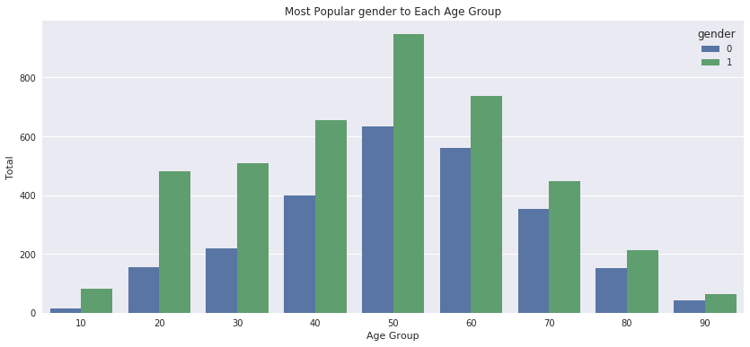

```python
plt.figure(figsize=(14, 6))
g = sns.countplot(x="age", hue="gender", data=X_test_2018)
plt.title('Most Popular gender to Each Age Group')
plt.ylabel('Total')
plt.xlabel('Age Group')
plt.xticks(rotation = 0)
plt.legend(title='gender')
plt.show();
```

#### What is the most offer type of gender in 2018 year ?

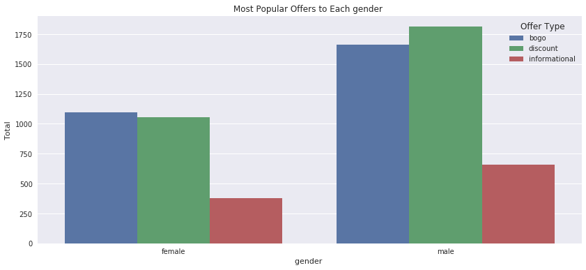

```python
plt.figure(figsize=(14, 6))
g = sns.countplot(x="gender", hue="offer_type", data=X_test_2018)
plt.title('Most Popular Offers to Each gender ')
plt.ylabel('Total')
plt.xlabel('gender ')
xlabels = ['female','male']
g.set_xticklabels(xlabels)
plt.xticks(rotation = 0)
plt.legend(title='Offer Type')
plt.show();
```

#### What is the most offer type age in 2018 year ?

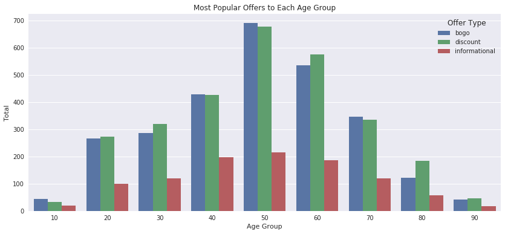

```python
plt.figure(figsize=(14, 6))
g = sns.countplot(x="age", hue="offer_type", data=X_test_2018)
plt.title('Most Popular Offers to Each Age Group')
plt.ylabel('Total')
plt.xlabel('Age Group')
plt.xticks(rotation = 0)
plt.legend(title='Offer Type')
plt.show();
```

## Predict

### What is the most gender and age in 2018 year ?

##### The male with age 50 years old is the most .

### What is the most offer type of gender in 2018 year ?

##### The male is the most than female .

### What is the most offer type age in 2018 year ?

##### The age 50 years old is the most age with bogo and discount offer type .

## Challenges

#### In table portfolio have column channels with array values how split it and convert to columns.

#### In table transcript have column value with 3 values how split it and convert to columns.

#### Github link

https://github.com/karimsoft/Starbucks_Capstone

#### Medium link

https://karimsoft.medium.com/karimsoft-starbucks-capstone-58821de875ac